# Publishing and Quarter Review

Week 9

Published

November 14, 2025

# Before we start

- No Discussion Section and Office Hours Next Week (but available by demand)
- Any questions?

# Agenda

- Quick Review
- Example of Quarto and Overleaf for Publishing

# Quarto for Publishing

Quarto and Overleaf are both excellent tools for publishing. For this class, itэs better to stick with Quarto – the scope of your projects makes it a suitable choice. However, if your papers become longer or you plan to collaborate with others, Overleaf is the better option.

Here is how to get started.

- [Paper Template for Quarto](https://github.com/gustavo-diaz/ps403/tree/main/paper_template).
- [Overleaf](https://www.overleaf.com). Click `New project` -> `Example project` to get started.

Helpful tips:

- [GitHub Desktop Tutorial](https://joshuadull.github.io/GitHub-Desktop/02-getting-started/index.html)
- [Exporting .bib file from Zotero](https://libguides.usask.ca/c.php?g=218034&p=1446406)
- Google Scholar has BibTeX citations!

[Download script](https://artur-baranov.github.io/nu-ps403-ds/scripts/ps403-d_09.qmd)

**Review**

First of all, load the usual libraries and the Transnational Justice dataset from the previous week.

```r
library(tidyverse)
library(marginaleffects)
library(GGally)

tjet = read.csv("data/tjet.csv")
```

Let’s explain under what circumstances countries adopt reparations policies. Could the involvement of international organizations influence a state’s decision to implement such policies?

- `rep_binary` presence of reparations policy
- `ICC_investigation` presence of ICC investigation
- `uninv` ongoing UN investigations, count
- `trials_domestic` count of domestic trials

First, let’s see if the probability of reparations (`rep_binary`) is increasing when ICC intervenes (`ICC_investigation`). Set up a `glm()` logit model.

```r
model_icc = ...
```

Present summary of the model.

```r
summary(model_icc)
```

Now, let’s draw the graph using `plot_predictions()` from `marginaleffects` library. What is worrisome?

```r
...(model_icc,
                 ... = c("ICC_investigation"))
```

Now, let’s add a couple of variables. Add `uninv` and `trials_domestic`.

```r
model_full = glm(rep_binary ~ ICC_investigation + ..., family = binomial, data = tjet)
```

Present `plot_predictions()` for `ICC_investigation` only.

```r
...
```

Finally, present the `modelsummary()` table for both models. Compare.

```r
modelsummary(list("ICC Model" = model_icc,
                  "Full Model" = model_full),
                   stars = c("*" = 0.05),
                   gof_omit = "AIC|BIC|Log.Lik|F|RMSE" ,
                   statistic = "p.value")
```

Don’t forget to clean the environment.

# Exploring Data

Today we are working with World Happiness Report data, the one we had on the [week 5](https://artur-baranov.github.io/nu-ps403-ds/ps403-d_05.html).

- `Country_name` is the name of the country
- `Ladder_score` is the happiness score
- `Continent`

Load the data.

```r
whr = read.csv("data/WHR.csv")
```

Explore the following variables with the `ggpairs()` function from `GGally`. What can you see on the graph?

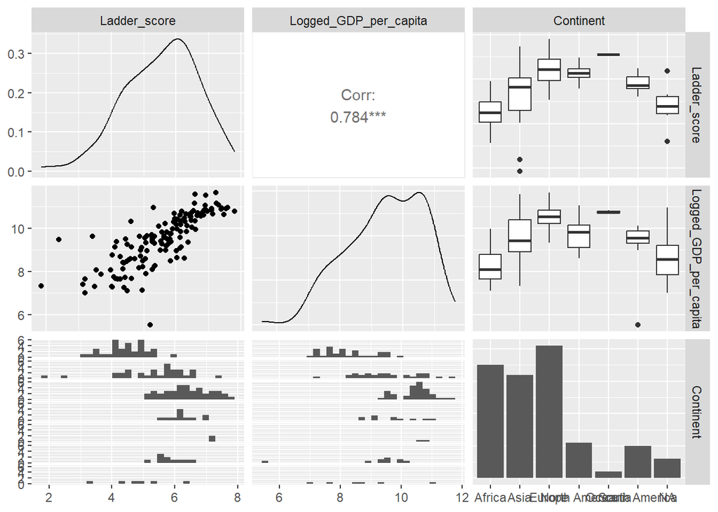

```r
library(GGally)
ggpairs(whr,
        columns = c("Ladder_score",
                    "Logged_GDP_per_capita",
                    "Continent"))
```

Let’s zoom in the Happiness Score by Continent. Is Africa different from Europe in terms of the Happiness?

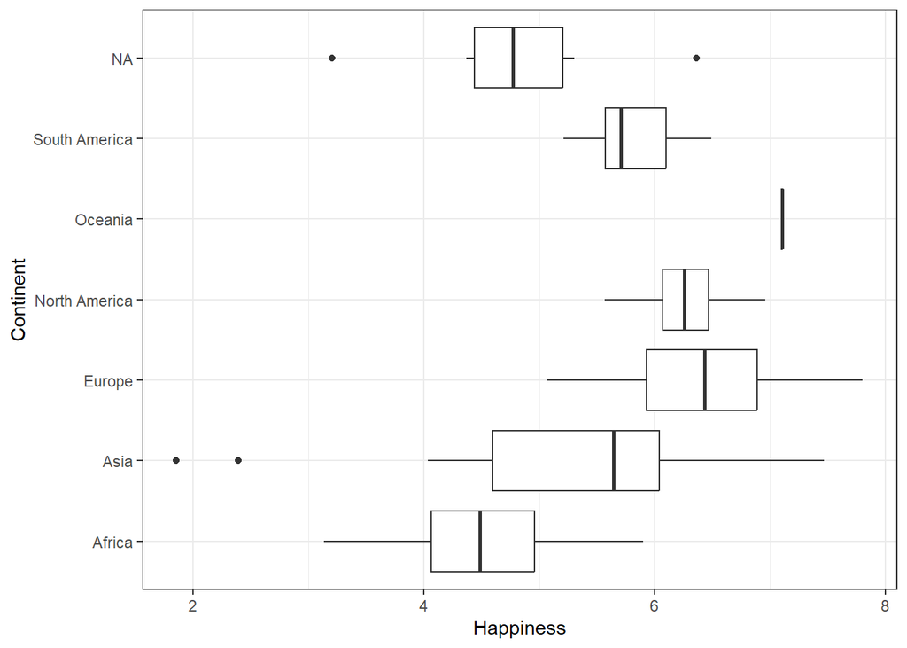

```r
ggplot(whr) +
  geom_boxplot(aes(x = Ladder_score, y = Continent)) +
  labs(x = "Happiness") +
  theme_bw()
```

Zoom in even more. Use `filter()` to leave only the continents we are analyzing. And leave only the variables we want to work with: `Country_name`, `Ladder_score`, `Continent` and `Logged_GDP_per_capita`.

```r
ae_whr = whr %>%
  filter(Continent %in% c("Africa", "Europe")) %>%
  select(Country_name, Ladder_score, Continent, Logged_GDP_per_capita)
```

Plot again. Make color more transparent with `alpha = 0.5`.

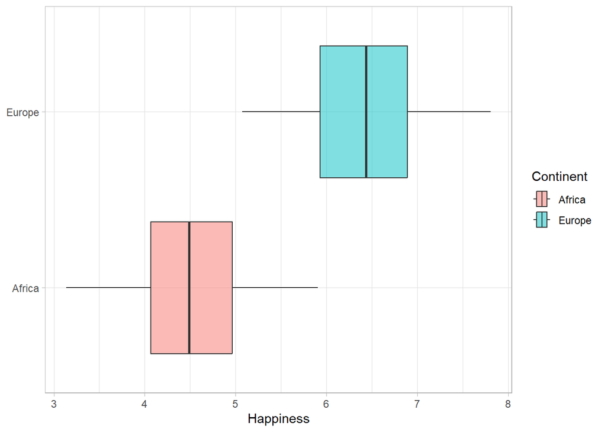

```r
ggplot(ae_whr) +
  geom_boxplot(aes(x = Ladder_score, y = Continent, fill = Continent), alpha = 0.5) +
  labs(x = "Happiness",
       y = NULL) +
  theme_light()
```

# Formal Tests

Finally, let’s test it. Interpret the results.

```r
t.test(ae_whr$Ladder_score ~ ae_whr$Continent)
```

```
    Welch Two Sample t-test

data:  ae_whr$Ladder_score by ae_whr$Continent
t = -12.395, df = 73.907, p-value < 2.2e-16
alternative hypothesis: true difference in means between group Africa and group Europe is not equal to 0
95 percent confidence interval:
 -2.277125 -1.646372
sample estimates:
mean in group Africa mean in group Europe
            4.447886             6.409634
```

We can confirm it with the simple model. Estimate the Happiness Score depending on the continent, and plot the confidence intervals for the estimate. Is it different from the boxplots?

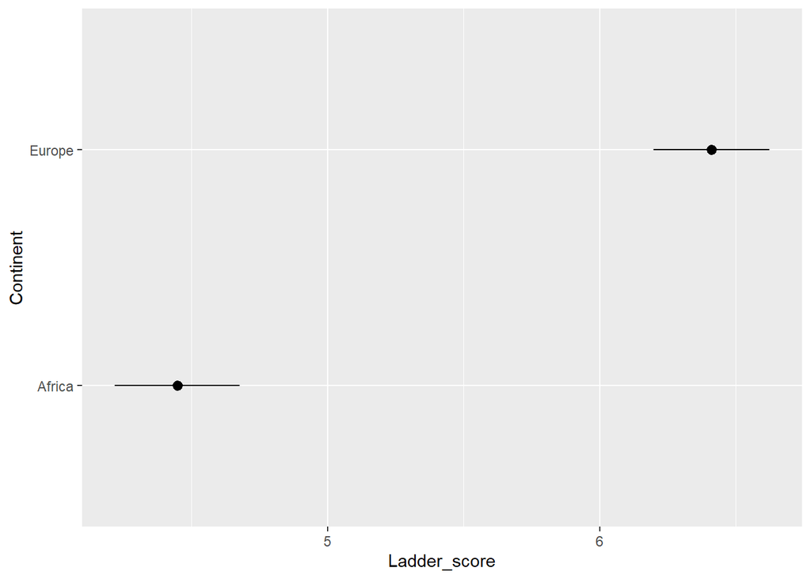

```r
lm(Ladder_score ~ Continent,
   ae_whr) %>%
  plot_predictions(by = "Continent") +
  coord_flip()
```

Now, let’s plug in the Wealth, measured as Log GDP per capita in the model. Explore difference.

```
Ignoring unknown labels:
• linetype : "Continent"
```

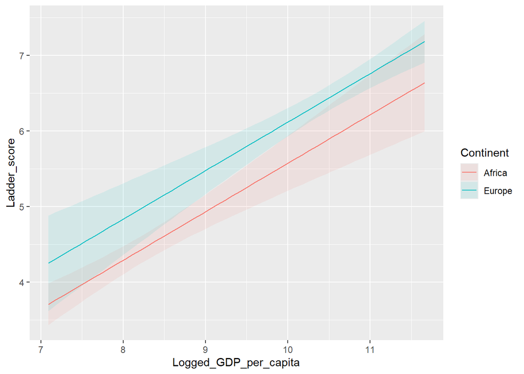

```r
model = lm(Ladder_score ~ Logged_GDP_per_capita + Continent, ae_whr)
plot_predictions(model,
                 condition = c("Logged_GDP_per_capita", "Continent"))
```

Present summary. Do `Continent` variable matter?

```r
summary(model)
```

```
Call:
lm(formula = Ladder_score ~ Logged_GDP_per_capita + Continent,
    data = ae_whr)

Residuals:
     Min       1Q   Median       3Q      Max
-1.90103 -0.34965  0.02907  0.32646  1.23085

Coefficients:
                      Estimate Std. Error t value Pr(>|t|)
(Intercept)           -0.84400    0.76697  -1.100   0.2748
Logged_GDP_per_capita  0.64181    0.09235   6.950 1.29e-09 ***
ContinentEurope        0.54416    0.23916   2.275   0.0258 *
---
Signif. codes:  0 '***' 0.001 '**' 0.01 '*' 0.05 '.' 0.1 ' ' 1

Residual standard error: 0.5426 on 73 degrees of freedom
Multiple R-squared:  0.8017,    Adjusted R-squared:  0.7963
F-statistic: 147.6 on 2 and 73 DF,  p-value: < 2.2e-16
```

Let’s add one more variable, and run the model on the whole dataset. What does it tell us?

```r
lm(Ladder_score ~ Social_support + Logged_GDP_per_capita + Continent, whr) %>%
  summary()
```

```
Call:
lm(formula = Ladder_score ~ Social_support + Logged_GDP_per_capita +
    Continent, data = whr)

Residuals:
     Min       1Q   Median       3Q      Max
-1.82847 -0.31606  0.02814  0.35224  1.14812

Coefficients:
                       Estimate Std. Error t value Pr(>|t|)
(Intercept)            -1.15661    0.49274  -2.347  0.02051 *
Social_support          4.34406    0.59174   7.341 2.52e-11 ***
Logged_GDP_per_capita   0.32703    0.06767   4.833 3.93e-06 ***
ContinentAsia          -0.04027    0.15293  -0.263  0.79275
ContinentEurope         0.25751    0.18574   1.386  0.16812
ContinentNorth America  0.58400    0.21045   2.775  0.00638 **
ContinentOceania        0.65633    0.42383   1.549  0.12405
ContinentSouth America  0.28415    0.21400   1.328  0.18670
---
Signif. codes:  0 '***' 0.001 '**' 0.01 '*' 0.05 '.' 0.1 ' ' 1

Residual standard error: 0.5394 on 123 degrees of freedom
  (6 observations deleted due to missingness)
Multiple R-squared:  0.7867,    Adjusted R-squared:  0.7746
F-statistic: 64.81 on 7 and 123 DF,  p-value: < 2.2e-16
```

# What’s next?

Congrats with finalizing the class! No optional exercises this time.

# What we have covered in coding

| Library | Functions | Description |
| --- | --- | --- |
| tidyverse | `filter()`, `mutate()`, `ggplot()` | data wrangling and visualization |
| modelsummary | `modelsummary()` | present good looking model summary tables |
| broom | `tidy()` | extract additional information from the models |
| marginaleffects | `plot_predictions()` | calculate and visualize marginal effects |
| GGally | `ggpairs()` | extension to ggplot |
| tinytable | `tt()` | present good looking tables |
| patchwork | `/`, `+` | plot several graphs together |

# Datasets we have used

| Dataset | Description | Link |
| --- | --- | --- |
| **V-Dem** | Measures democracy worldwide | [V-Dem](https://www.v-dem.net/) |
| **World Happiness Report** | Annual happiness report | [World Happiness Report](https://worldhappiness.report/) |
| **Who Governs** | Dataset on political elites | [Who Governs](https://doi.org/10.1017/S0003055420000490) |
| **SIPRI** | Data on military operations | [SIPRI](https://www.sipri.org/databases) |
| **Comparative Political Data Set** | A dataset covering political institutions | [CPDS](https://www.cpds-data.org/) |
| **World Values Survey** | Survey measuring values across the globe | [WVS](https://www.worldvaluessurvey.org/wvs.jsp) |
| **Transitional Justice Evaluation Tools Dataset** | Dataset assessing transitional justice | [TJET Dataset](https://transitionaljusticedata.org) |

# Check List

- I know that every lab has check list below! And I will use it to navigate what we have learned
- R doesn’t scare me anymore
- I have developed the intuition behind application of quantitative methods and happy to learn more!